# Specifications for MSE Trials for Atlantic Tropical Tunas

## 1 Introduction

The tropical tunas (TT) fishery, under the management of the International Commission for the Conservation of Atlantic Tuna (ICCAT), is undergoing a management strategy evaluation (MSE) process. This fishery mainly target bigeye (BET), skipjack (SKJ), and yellowfin (YFT) tunas.

**NoteManagement strategy evaluation**

Process used in fisheries management to simulate and assess the performance of different management strategies under varying conditions and uncertainties (Figure 1).

There are three main components in an MSE process:

- **Operating models (OMs)**: a collection of mathematical/statistical models that describe alternative hypotheses of the historical fishery dynamics and specifications for simulating the collection of data and implementation of management measures in the future;
- **Candidate management procedures (CMPs)**: a set of proposed algorithms that generate management recommendations from fishery data and will be evaluated in the MSE;
- **Performance indicators (PIs)**: statistics used to quantitatively evaluate the CMPs against specified management objectives.

The OMs, CMPs, and PIs are developed as a collaborative effort between scientists, decision-makers, and other stakeholders in the fishery.

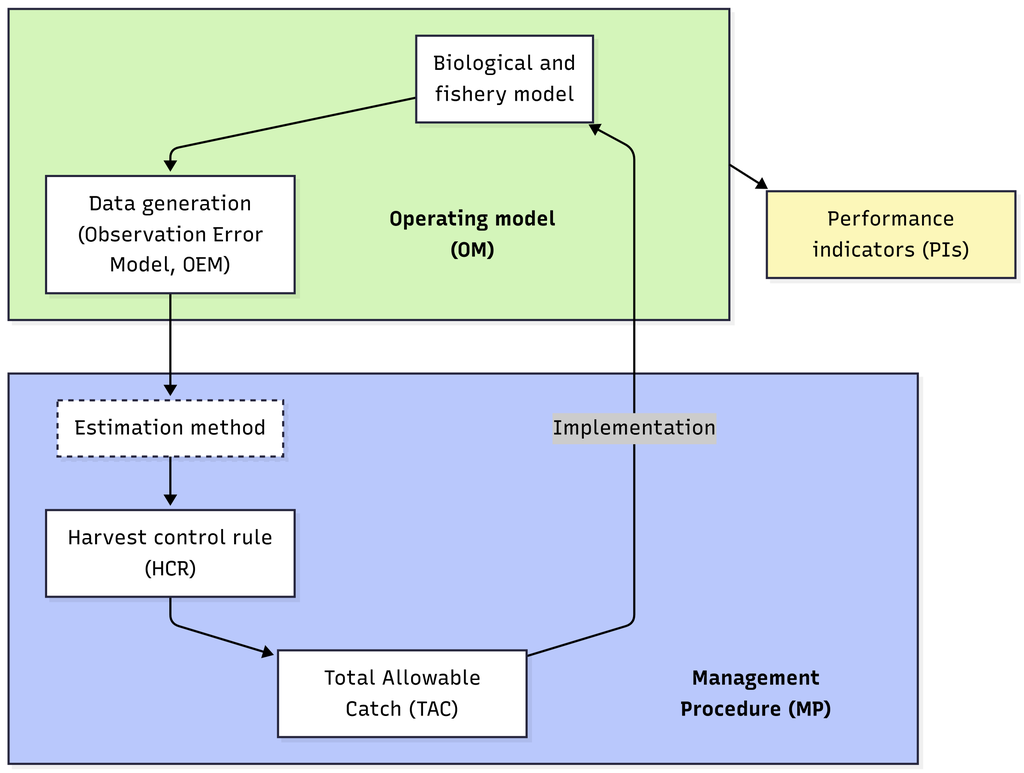

Figure 1: Management strategy evaluation (MSE) framework.

### 1.1 About this document

This document describes the specifications for the OMs, CMPs, and PIs that have been proposed and developed for the TT fishery. It is a living document and will be continued to be updated so that it reflects the current state of the multi-stock TT MSE process. Members of the Tropical Tuna Species Group (TTSG) are encouraged to provide feedback, comments, or edits to any part of this document.

The document is written using the [Quarto](https://quarto.org/) format and can edited in any text editor. The source document is available on the [MSE GitHub repository](https://github.com/ICCAT/multitro-mse). TTSG members can make edits to the document either directly in the online repository or by cloning the repository and submitting pull requests with their edits. Alternatively, they can email questions or comments to the authors. The former approach has the advantage that all comments, questions, and edits are immediately visible to all members of the TTSG. The [Discussions feature](https://docs.github.com/en/discussions/quickstart#creating-a-new-discussion) on the Github repository can also be used to post questions, comments, or points for discussion related to any aspect of this document or the MSE process in general.

This document is available at the [TT MSE homepage](https://iccat.github.io/multitro-mse/).

## 2 MSE framework

The R software has been used to developed the MSE code for the TT fishery. All code is open-source and can be found on the [MSE GitHub repository](https://github.com/ICCAT/multitro-mse).

The code developed for the TT MSE uses the FLBEIA framework. FLBEIA (Garcia et al., 2017) is an R package that has been developed for conducting bio-economic evaluation of fisheries management strategies. The software allows the bio-economic evaluation of a wide range of management strategies in a great variety of case studies such as multi-stock, multi-fleet, stochastic and seasonal configurations. FLBEIA is built using FLR libraries. [FLR](https://flrproject.org/) is a collaborative project oriented to develop quantitative fisheries management tools.

## 3 Stock assessment

In this section, we describe the main aspects of the last stock assessment models for BET, SKJ, and YFT, which were then used to condition the OMs. These assessments use the areas-as-fleets approach, which aims to account for the regional differences in fishing behavior and selectivity using a single-area model configuration (Waterhouse et al., 2014). These regions are shown in Figure 2.

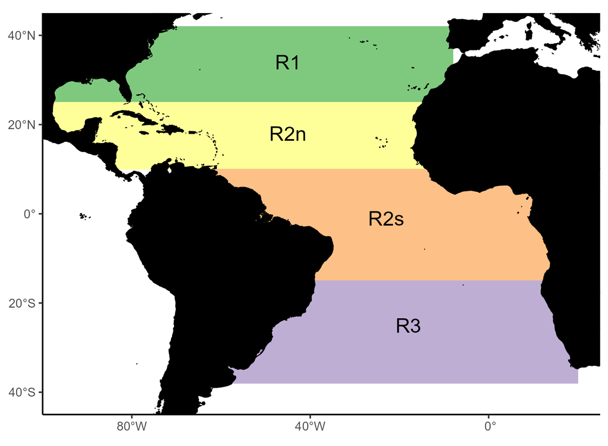

Figure 2: Definition of regions used in the stock assessment models for the three TT stocks.

### 3.1 Bigeye

The last stock assessment was conducted in 2025 (ICCAT, 2025) using the Stock Synthesis (SS3) platform (Methot and Wetzel, 2013). The data used in the BET assessment and the structure and assumptions of the assessment model are summarized in the sections below.

Table 1: Fishing fleets included the BET stock assessment. See Figure 2 for the definition of regions. The last column indicates if the fleet had an associated index of abundance (catch-per-unit-effort, CPUE).

[output not shown]

#### 3.1.1 Data

The period covered was from 1950 to 2023. The assessment mainly used landings data from longline (LL), purse seine (PS), and baitboat (BB) fleets, with a total of 22 fleets included in the model (Table 1 and Figure 3). There were two indices of abundance: one derived from either echosounder buoys or catch and effort data from purse seiners operating on floating objects, and one derived from the LL Japan in region 2 (Figure 4). The catchability coefficients for the CPUE indices were assumed to be time-invariant.

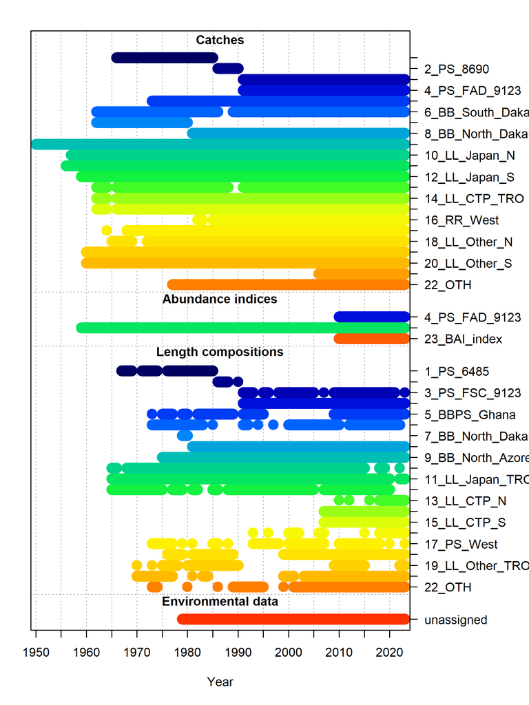

Figure 3: Summary of the data used in the BET stock assessment.

Length composition data for most fleets (excluding handline Brazil) were included in the model (Figure 3). The effective sample size (ESS) for the length composition data was established by adjusting ESS until unity was reached between modeled ESS and the Francis suggested sample size (Francis, 2011).

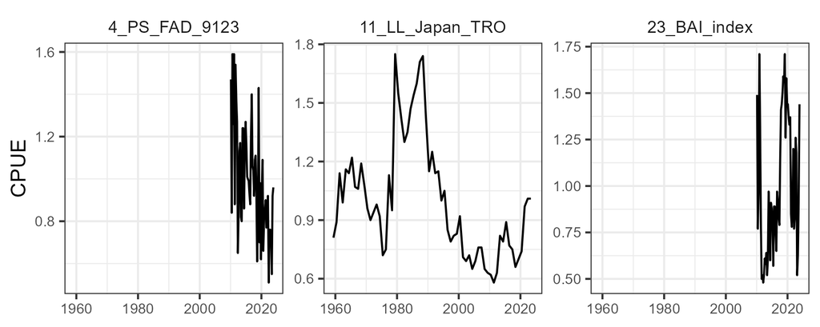

Figure 4: Indices of abundance (CPUE) included in the BET assessment model.

#### 3.1.2 Model structure

The model was configured yearly with four seasons per year, one sex, one area, and a total of 11 age groups (0 to 10+). The spawning timing was January 1st.

#### 3.1.3 Biological Parameters

Natural mortality was age-specific and parametrized following Lorenzen (2005) and Hamel and Cope (2022), assuming three levels of average natural mortality for adults: 0.26, 0.32, and 0.39. Maturity-at-age was knife-edge, with 50% at age-3 and 100% thereafter. Fecundity was proportional to body weight. Growth was parametrized following the Richards curve (Richards, 1959). Variability of lengths-at-age was assumed to be a function of mean length-at-age. Figure 5 shows a summary of the biological parametrization.

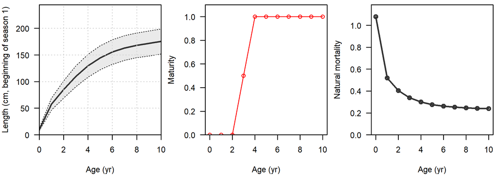

Figure 5: Growth, maturity, and natural mortality parametrized in the BET assessment model. Natural mortality assumed average natural mortality of 0.26 for adults.

#### 3.1.4 Stock-Recruitment

Expected recruitment to age-0 was calculated from the total spawning stock biomass using the Beverton-Holt stock-recruit function. Recruitment settlement was assumed to occur at month 1, 4, 7, and 10 (i.e., start of every season). The standard error for the log-normally distributed recruitment deviations (sigmaR) was fixed to 0.4. Steepness was fixed to values of 0.7, 0.8, or 0.9.

#### 3.1.5 Selectivity

Selectivity was modelled as a function of length and was assumed to be time-invariant. Dome-shaped selectivity was allowed for several LL and BB fleets, while cubic splices were used for PS and some BB fleets.

### 3.2 Skipjack

The last stock assessment was conducted in 2022 (ICCAT, 2022) using the SS3 platform. The data used in the SKJ assessment and the structure and assumptions of the assessment model are summarized in the sections below.

Table 2: Fishing fleets included the SKJ stock assessment. See Figure 2 for the definition of regions. The last column indicates if the fleet had an associated index of abundance (CPUE).

| Fleet code | Description | Region | CPUE included? |
| --- | --- | --- | --- |
| 1_PS_6385 | Purse seine EU (Spain, France) | East R1/R2/R3 | No |
| 2_PS_8690 | Purse seine EU (Spain, France) | East R1/R2/R3 | No |
| 3_PS_FSC_91 | Purse seine free school | East R1/R2/R3 | No |
| 4_PS_FAD_91 | Purse seine FADs | East R1/R2/R3 | Yes |
| 5_PSBB_Ghana | Ghana baitboat and purse seine | East R1/R2/R3 | No |
| 6_PSBB_SouthDakar | Baitboat South Dakar | East R2s/R3 | No |
| 7_PSBB_Dakar62-80 | Baitboat Dakar | East R2n | No |
| 8_PSBB_Dakar81 | Baitboat Dakar | East R2n | No |
| 9_BB_North25Lat | Baitboat North25 | East R1 | Yes |
| 10_LL | All longline fleets | East R1/R2/R3 | No |
| 11_Acoustic_Buoy | Acoustic buoy index | East R1/R2/R3 | Yes |

#### 3.2.1 Data

The period covered was from 1950 to 2020. The assessment mainly used landings data from LL, PS, and BB fleets, with a total of 11 fleets included in the model (Table 2 and Figure 6). There were a total of three indices of abundance available for the assessment: one derived from echosounder information from buoys ($11\_Acoustic\_Buoy$), one derived from PS operating on fishing aggregating devices catch and effort information ($4\_PS\_FAD\_91$), and one derived from the BB in region 1 (Figure 7). The $4\_PS\_FAD\_91$ and $11\_Acoustic\_Buoy$ indices were not included together in a model run. The catchability coefficients for the CPUE indices were assumed to be time-invariant.

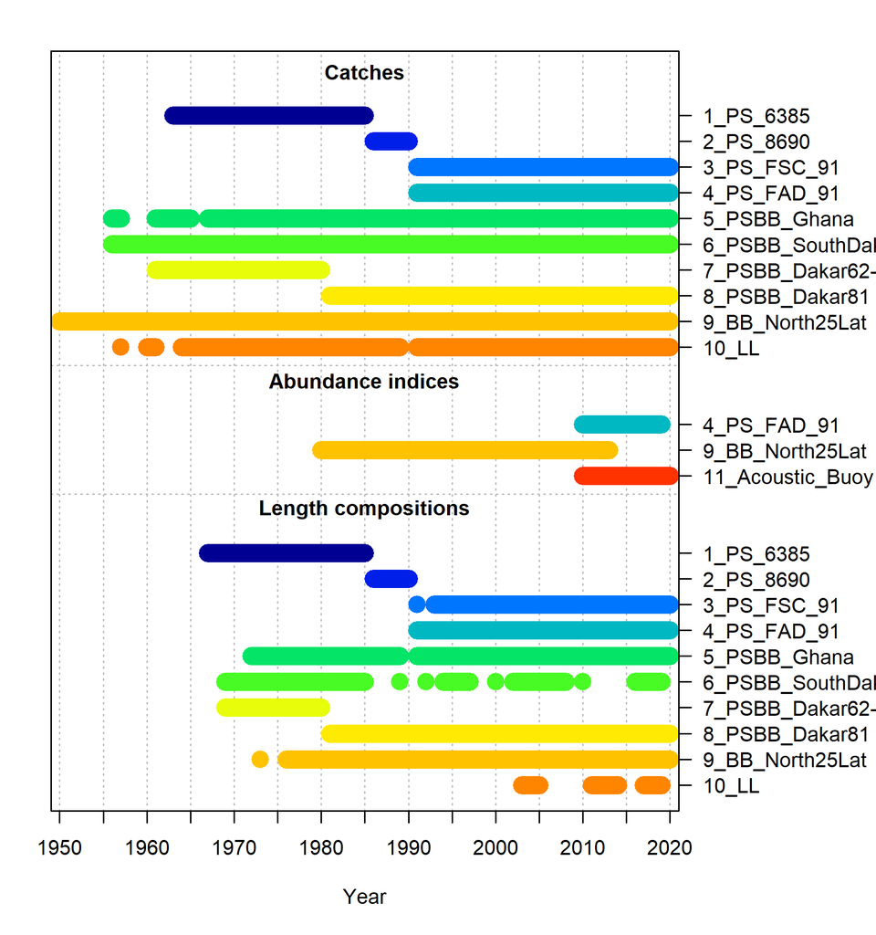

Figure 6: Summary of the data used in the SKJ stock assessment.

Length composition data for all fleets were included in the model (Figure 6). The ESS for the length composition data was established by adjusting ESS until unity was reached between modeled ESS and the Francis suggested sample size (Francis, 2011).

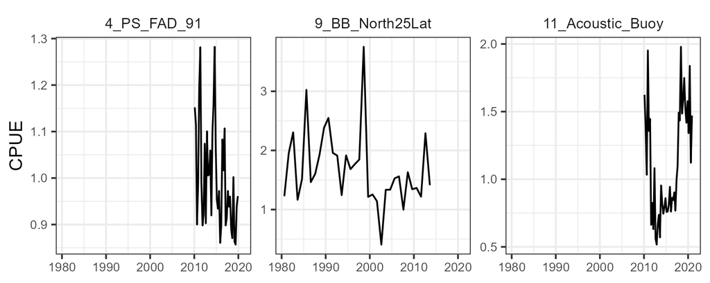

Figure 7: Indices of abundance (CPUE) included in the SKJ assessment model.

#### 3.2.2 Model structure

The model was configured yearly with four seasons per year, one sex, one area, and a total of 7 age groups (0 to 6+). The spawning timing was January 1st.

#### 3.2.3 Biological Parameters

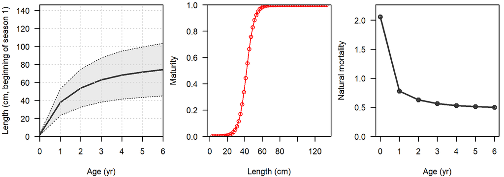

Figure 8: Growth, maturity, and natural mortality parametrized in the SKJ assessment model. Growth used the 0.5 quantile (see ICCAT (2022)).

#### 3.2.4 Stock-Recruitment

Expected recruitment to age-0 was calculated from the total spawning stock biomass using the Beverton-Holt stock-recruit function. Recruitment settlement was assumed to occur at month 1, 4, 7, and 10 (i.e., start of every season). sigmaR was fixed to 0.4 and steepness was fixed to values of 0.7, 0.8, or 0.9.

#### 3.2.5 Selectivity

Selectivity was modelled as a function of length and was assumed to be time-invariant. Dome-shaped selectivity was allowed for most fleets, while a logistic shape was modelled for the LL fleet.

### 3.3 Yellowfin

The last stock assessment was conducted in 2024 (ICCAT, 2024) using the SS3 platform. The data used in the YFT assessment and the structure and assumptions of the assessment model are summarized in the sections below.

Table 3: Fishing fleets included the YFT stock assessment. See Figure 2 for the definition of regions. The last column indicates if the fleet had an associated index of abundance (catch-per-unit-effort, CPUE).

| Fleet code | Description | Region | CPUE included? |
| --- | --- | --- | --- |
| 1_PS_ESFR_6585 | Purse seine EU (Spain, France) | R2/R1 | No |
| 2_PS_ESFR_8690 | Purse seine EU (Spain, France) | R2/R1 | No |
| 3_PS_ESFR_FS_9122 | Purse seine free school EU (Spain, France) | R2/R1 | Yes |
| 4_PS_ESFR_FOB_9122 | Purse seine FADs EU (Spain, France) | R2/R3 | Yes |
| 5_BB_PS_Ghana_6522 | Ghana baitboat and purse seine | R2 | No |
| 6_BB_area2_Sdak | Baitboat South Dakar | R2s | No |
| 7_BB_DAKAR_6280 | Baitboat North Dakar | R2n | No |
| 8_BB_DAKAR_8122 | Baitboat North Dakar | R2n | No |
| 9_North_BB_Azores | Baitboat North Azores | R1 | No |
| 10_Japan_LL_N | Longline North Japan | R1 | Yes |
| 11_Japan_LL_TRO | Longline Tropical Japan | R2 | Yes |
| 12_Japan_LL_S | Longline South Japan | R3 | Yes |
| 13_Other_LL_N | Longline North Other | R1 | No |
| 14_Other_LL_TRO | Longline Tropical Other | R2 | No |
| 15_Other_LL_S | Longline South Other | R3 | No |
| 16_HL_Braz_N | Handline Brazil | R2 | No |
| 17_US_RR | RR West Atlantic | R1 | No |
| 18_PS_WEST | Purse seine West Atlantic | R1 | No |
| 19_OTH_OTH | Other | R1/R2/R3 | No |

#### 3.3.1 Data

The period covered was from 1950 to 2022. The assessment mainly used landings data from LL, PS, and baitboat BB fleets, with a total of 19 fleets included in the model (Table 3 and Figure 9). There were a total of five indices of abundance available for the assessment: one derived from PS operating on floating objects catch and effort data ($4\_PS\_ESFR\_FOB\_9122$), one derived from PS operating on free schools catch and effort data ($4\_PS\_ESFR\_FS\_9122$), and three indices derived from LL for region 1, 2, and 3 (Figure 10). The catchability coefficients for the CPUE indices were assumed to be time-invariant.

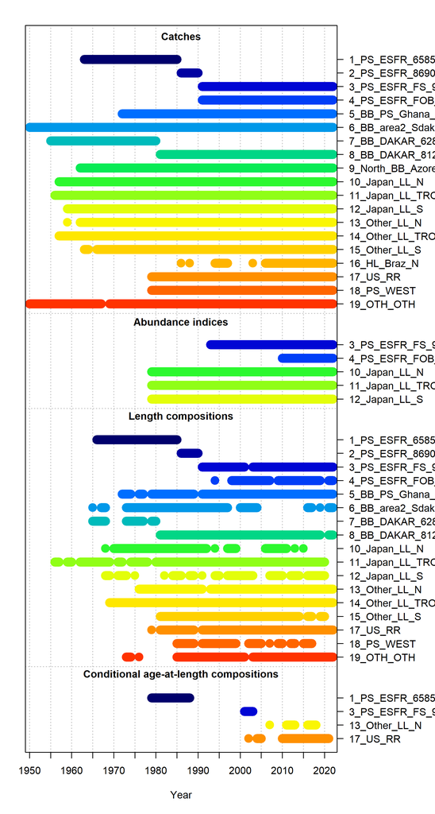

Figure 9: Summary of the data used in the YFT stock assessment.

Length composition data for most fleets were included in the model (Figure 9). The ESS for the length composition data was established by adjusting ESS until unity was reached between modeled ESS and the Francis suggested sample size (Francis, 2011). Conditional age-at-length (CAAL) data was also included for four fleets (Figure 9).

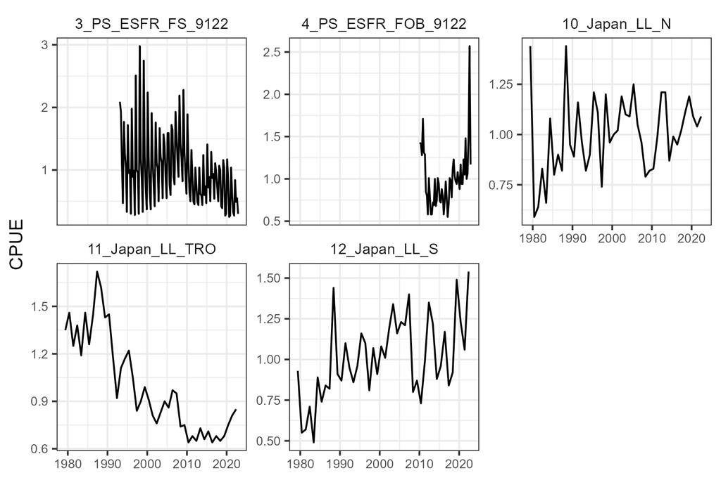

Figure 10: Indices of abundance (CPUE) included in the YFT assessment model.

#### 3.3.2 Model structure

The model was configured yearly with four seasons per year, one sex, one area, and a total of 11 age groups (0 to 10+). The spawning timing was January 1st.

#### 3.3.3 Biological Parameters

Natural mortality (M) was age-specific and parametrized following Lorenzen (1996), with a reference M ($M_{ref}$) equal to 0.3 for age 7 assuming a maximum age of 18 years (Hamel and Cope, 2022). Alternative $M_{ref}$ values of 0.25 and 0.35 were also tested. Maturity-at-length followed a logistic function. Fecundity was proportional to body weight. Growth was parametrized following the Richards curve (Richards, 1959). Variability of lengths-at-age was assumed to be a function of mean length-at-age. Figure 11 shows a summary of the biological parametrization.

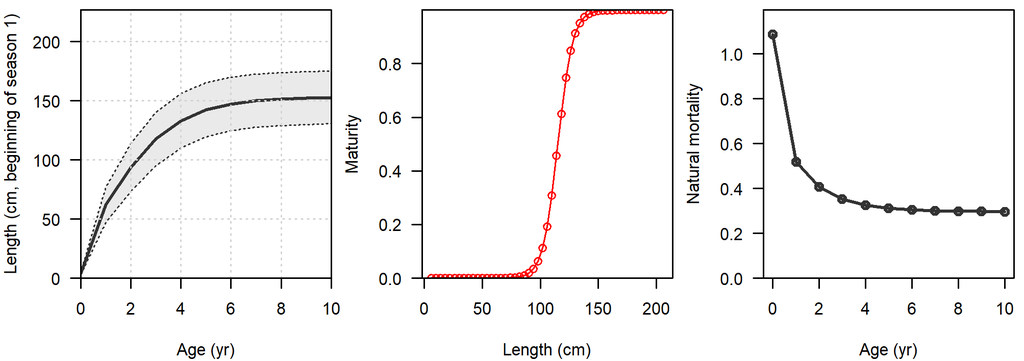

Figure 11: Growth, maturity, and natural mortality parametrized in the YFT assessment model. $M_{ref}$ was 0.3.

#### 3.3.4 Stock-Recruitment

Expected recruitment to age-0 was calculated from the total spawning stock biomass using the Beverton-Holt stock-recruit function with flat-top beyong unfished biomass. Recruitment settlement was assumed to occur at month 1, 4, 7, and 10 (i.e., start of every season). sigmaR was freely estimated and steepness was fixed to 0.7, 0.8, or 0.9.

#### 3.3.5 Selectivity

Selectivity was modelled as a function of length and was assumed to be time-invariant. Dome-shaped selectivity was modelled for most LL and BB fleet, while cubic splines was modelled for the PS fleets.

## 4 Operating Models

### 4.1 Reference OMs

Table 4: Description of the axes of uncertainty for each stock.

|  | Description | Code |
| --- | --- | --- |
| Bigeye |  |  |
| Axis 1 | Average natural mortality for adults: 0.26, 0.32, 0.39 | M0.26, M0.32, M0.39 |
| Axis 2 | Steepness: 0.7, 0.8, 0.9 | h0.7, h0.8, h0.9 |
| Axis 3 | Index of abundance: echosounder buoys (BAI) or catch/effort PSLS | BAI, PS |
| Skipjack |  |  |
| Axis 1 | Index of abundance: acoustic buoy or PSFAD catch and effort | noPS, noBuoy |
| Axis 2 | Growth quantile: 0.25, 0.5, 0.75 | 25thGrowth, 50thGrowth, 75thGrowth |
| Axis 3 | Steepness: 0.7, 0.8, 0.9 | h0.7, h0.8, h0.9 |
| Yellowfin |  |  |
| Axis 1 | M reference value: 0.35, 0.3, 0.25 | highM, midM, lowM |
| Axis 2 | Steepness: 0.7, 0.8, 0.9 | h07, h08, h09 |

### 4.2 Robustness OMs

The TT MSE evaluated the impacts of potential decrease in the mean recruitment level in future years. To do so, the $R_0$ parameter of the Beverton-Holt relationship decreased by 20% in the simulation period (Figure 12) from the estimated values in the Reference OMs for the three stocks. This set of runs with smaller $R_0$ is our Robustness OMs.

Robustness scenario are currently under development.

### 4.3 Validation

#### 4.3.1 Summary Report

Summary reports summarize the estimated parameters, the calculated biological reference points, and the estimated stock status relative to those reference points per stock (Table 5).

Table 5: OM summary reports.

| Stock | Report |
| --- | --- |
| Bigeye | See Summary report |
| Skipjack | See Summary report |
| Yellowfin | See Summary report |

#### 4.3.2 Diagnostic Reports

Individual diagnostic reports with objective function values and plots of model fits and patterns in residuals are available for each of the Reference OMs. Table 6 presents the diagnostics reports for all models in the uncertainty grid for each stock.

Table 6: OM diagnostics reports per stock. See Table 4 for more information on the axes of uncertainty.

| Bigeye | Skipjack | Yellowfin |
| --- | --- | --- |
| M0.26_h0.7_BAI | noBuoy_25thGrowth_h0.7 | highM_h07 |
| M0.26_h0.7_PS | noBuoy_25thGrowth_h0.8 | highM_h08 |
| M0.26_h0.8_BAI | noBuoy_25thGrowth_h0.9 | highM_h09 |
| M0.26_h0.8_PS | noBuoy_50thGrowth_h0.7 | lowM_h07 |
| M0.26_h0.9_BAI | noBuoy_50thGrowth_h0.8 | lowM_h08 |
| M0.26_h0.9_PS | noBuoy_50thGrowth_h0.9 | lowM_h09 |
| M0.32_h0.7_BAI | noBuoy_75thGrowth_h0.7 | midM_h07 |
| M0.32_h0.7_PS | noBuoy_75thGrowth_h0.8 | midM_h08 |
| M0.32_h0.8_BAI | noBuoy_75thGrowth_h0.9 | midM_h09 |
| M0.32_h0.8_PS | noPS_25thGrowth_h0.7 |  |
| M0.32_h0.9_BAI | noPS_25thGrowth_h0.8 |  |
| M0.32_h0.9_PS | noPS_25thGrowth_h0.9 |  |
| M0.39_h0.7_BAI | noPS_50thGrowth_h0.7 |  |
| M0.39_h0.7_PS | noPS_50thGrowth_h0.8 |  |
| M0.39_h0.8_BAI | noPS_50thGrowth_h0.9 |  |
| M0.39_h0.8_PS | noPS_75thGrowth_h0.7 |  |
| M0.39_h0.9_BAI | noPS_75thGrowth_h0.8 |  |
| M0.39_h0.9_PS | noPS_75thGrowth_h0.9 |  |

### 4.4 Conditioning

The Reference OMs were conditioned in FLBEIA with the same biological configuration. The conditioned fleet structure in the OMs is shown in Table 7.

Table 7: Fleet conditioning in the OMs.

| Fleet | Description | Bigeye | Skipjack | Yellowfin |
| --- | --- | --- | --- | --- |
| PS | Purse seine, divided in two metiers: FSC (free school) and LS (log school) |  |  |  |
| PSBB_GH | Purse seine and baitboat Ghana |  |  |  |
| Dakar_BB | Dakar baitboat |  |  |  |
| North_BB | North baitboat |  |  |  |
| JP_LL | Japan longline |  |  |  |
| Other_LL | Other longline |  |  |  |
| CTP_LL | Chinese Taipei longline |  |  |  |
| RR_US | RR U.S. |  |  |  |
| HL_Bra | Handline Brazil |  |  |  |
| West_PS | West purse seine |  |  |  |
| Others | Other gears |  |  |  |

The historical period in the MSE corresponds to the years covered in the assessment model (Figure 12). On the other side, the simulation period corresponds to the years when the harvest control rules (HCR) are evaluated. The simulation period started in 2026 and ended in 2057. Since some assessments ended prior to this year, some initial runs were needed for those stocks assuming observed and average catches from the last years (“Initial runs”, Figure 12).

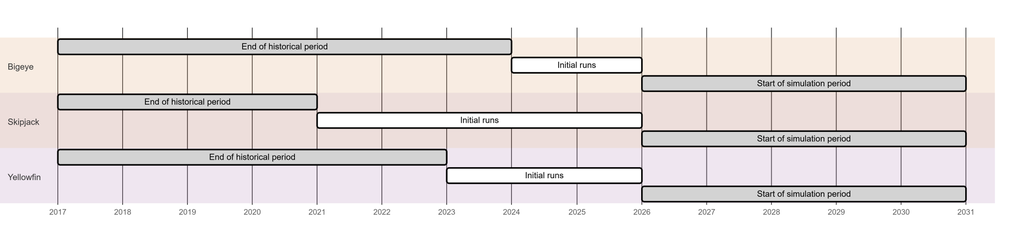

Figure 12: Periods in the MSE.

#### 4.4.1 Observation error model

Autocorrelation in CPUE residuals were introduced in the historical and simulation periods for all the Reference OMs based on the calculated autocorrelation coefficient at lag 1 (Figure 13).

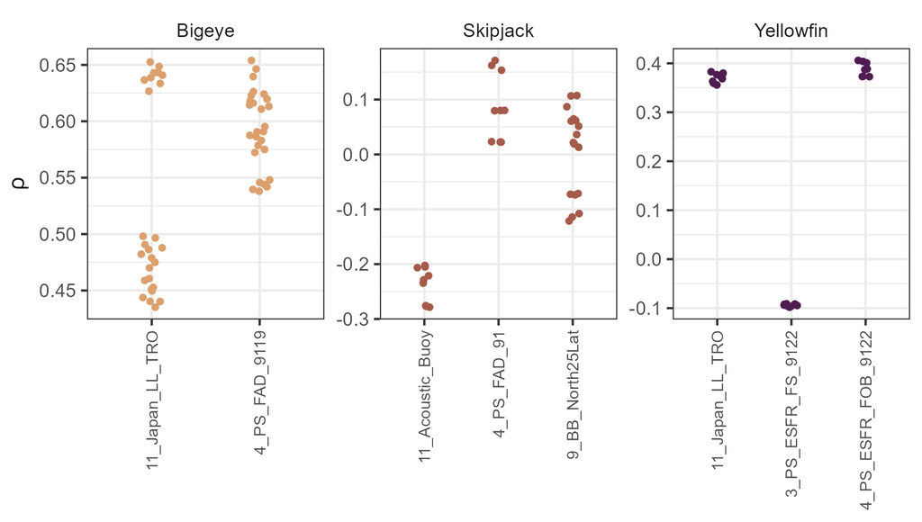

Figure 13: Autocorrelation coefficient ($\rho$) at lag 1 for abundance indices per stock. Dots represent different model configurations in the uncertainty grid.

## 5 Candidate Management Procedures

The management advice is given every three years (*management period*) and the total allowable catch (TAC) is derived from the candidate MP. The candidate MP was run in the last year of each management period, including information up to the previous year. The TAC derived from the MP was set for the next management period (Figure 14).

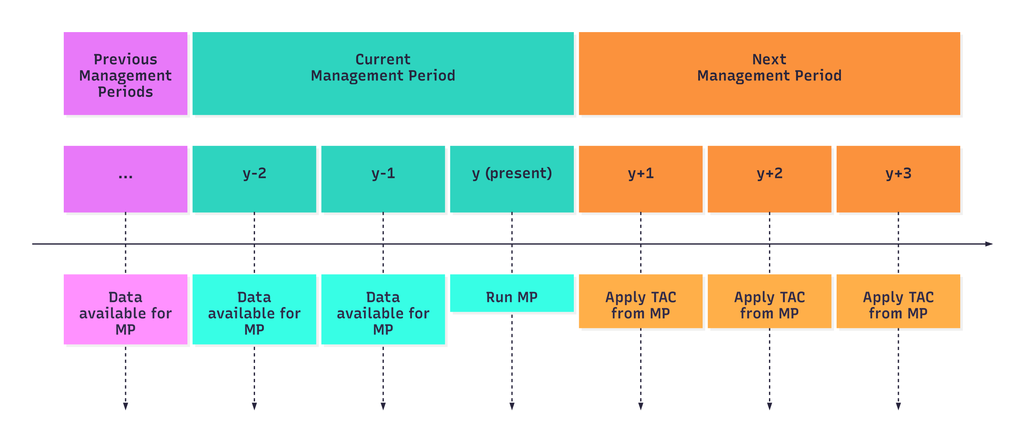

Figure 14: Representation of the TAC calculation for the next management period.

### 5.1 Pseudo-constant catch

The total allowable catch (TAC) for the next management period ($\{y+1,y+2,y+3\}$) is assumed constant, unless $\bar{J}$, derived from the index of abundance in the preceding three years, falls below a reference value $J_{ref}$ (see Figure 15):

$$TAC_{\{y+1,y+2,y+3\}} =
\begin{cases}
TAC_{ct}, & \text{if }\bar{J} \geq J_{ref} \\
TAC_{ct}(\frac{\bar{J}}{J_{ref}}), & \text{if }\bar{J} < J_{ref}
\end{cases}$$

Table 8 shows the $J_{ref}$ values used for each stock. $\bar{J}$ was derived from from index of abundance values from the preceding three years:

$$\bar{J} = \frac{J_{y-1}+J_{y-2}+J_{y-3}}{3}$$

Where $J$ represents the index of abundance (see Table 8). In addition, the TAC variation between consecutive management periods $TAC_{\{y+1,y+2,y+3\}}$ and $TAC_{\{y-2,y-1,y\}}$ could not exceed 15%.

Table 8: HCR parameters for pseudo-constant catch MP.

| Stock | $J_{ref}$ | $TAC_{ct}$ | Index ($J$) |
| --- | --- | --- | --- |
| YFT | 0.6 | 120,000 | Joint longline |
| BET | 0.8 | 75,000 | Joint longline |
| SKJ | 0.7 | 220,000 | Acoustic buoy |

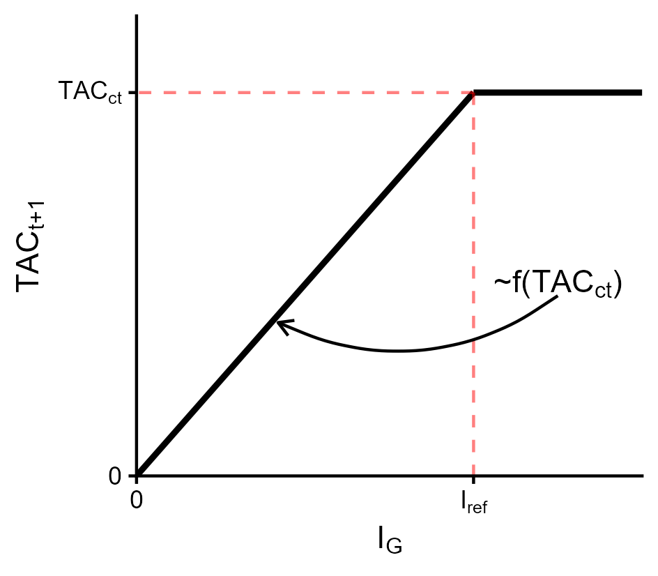

Figure 15: Derivation of the TAC for the next management period ($TAC_{\{y+1,y+2,y+3\}}$) in the pseudoconstant catch MP.

### 5.2 Index-based

The total allowable catch (TAC) for the next management period ($\{y+1,y+2,y+3\}$) is calculated from the TAC in the current management period $\{y-2,y-1,y\}$ and a factor $J_{rat}$ derived from the index of abundance (see Table 8). We derive the ratio of change in the index of abundance $J$ between the last three years ($y-1$, $y-2$, and $y-3$) and the preceding three years ($y-4$, $y-5$, and $y-6$):

$$J_{rat} = \frac{J_{y-1}+J_{y-2}+J_{y-3}}{J_{y-4}+J_{y-5}+J_{y-6}}$$

Then, the TAC for the next management period is obtained:

$$TAC_{\{y+1,y+2,y+3\}} = J_{rat} TAC_{\{y-2,y-1,y\}}$$

We imposed a TAC variability restriction between consecutive management periods $TAC_{\{y+1,y+2,y+3\}}$ and $TAC_{\{y-2,y-1,y\}}$ of 15% maximum.

In addition, $TAC_{\{y+1,y+2,y+3\}}$ was restricted to be equal or lower than a maximum TAC (see Table 9).

Table 9: Maximum TAC imposed in the index-based MP.

| Stock | $TAC_{max}$ |
| --- | --- |
| YFT | 140,000 |
| BET | 80,000 |
| SKJ | 240,000 |

### 5.3 Model-based

Simulated data was included in a stochastic surplus production model in continuous time (SPiCT). SPiCT is a full state-space model, where biomass and fishing dynamics are modelled as states, which are observed indirectly through biomass indices and commercial catches sampled with error (Pedersen and Berg, 2017). SPiCT calculates maximum sustainable yield (MSY) reference points and is able to make short-term projections. SPiCT is the estimation method in the MSE.

Data included in SPiCT were simulated catches and indices of abundance as shown in Table 8. In addition to the acoustic buoy index, SKJ SPiCT models also included a purse seine FAD index derived from catch and effort information.

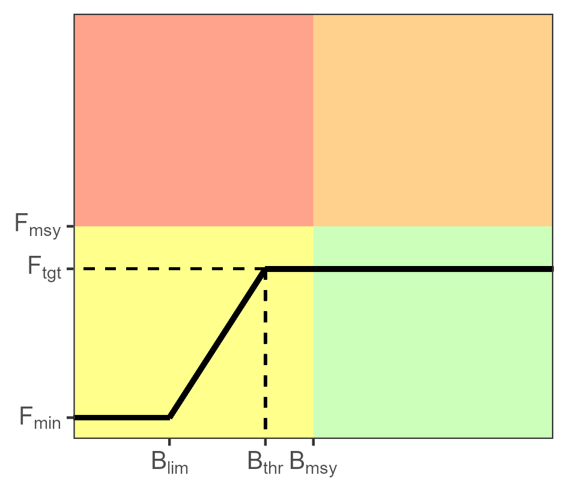

Figure 16: Example of HCR in model-based MPs.

TAC is derived from a harvest control rule based on stock status estimate (Figure 16). In the HCR, $F_{tgt}$ and $B_{thr}$ need to be defined, and the following options were tested (Figure 17):

- $F_{tgt}=0.8F_{msy}$ and $B_{thr}=B_{msy}$
- $F_{tgt}=0.9F_{msy}$ and $B_{thr}=B_{msy}$
- $F_{tgt}=F_{msy}$ and $B_{thr}=B_{msy}$

In addition, $B_{lim}=0.4\times B_{msy}$ and $F_{mim}=0.1\times F_{msy}$ for all cases. A maximum TAC restriction ($TAC_{max}$) could also be applied in some scenarios (Table 10). TAC variation between consecutive management periods $TAC_{\{y+1,y+2,y+3\}}$ and $TAC_{\{y-2,y-1,y\}}$ could not exceed 15%.

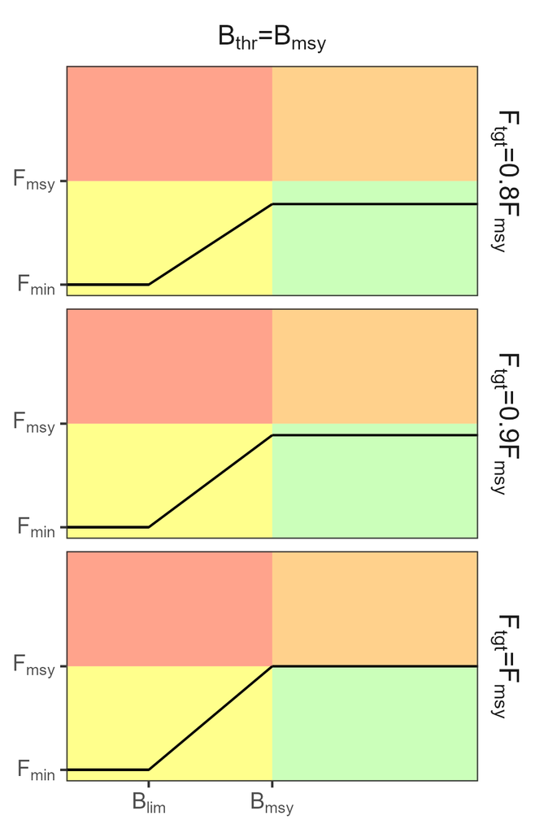

Figure 17: HCR evaluated in the MSE. These HCR come from combinations of $F_{tgt}$ (rows) and $B_{thr}$ (columns).

Table 10: Maximum TAC restriction applied in some model-based MPs.

| Stock | $TAC_{max}$ |
| --- | --- |
| YFT | 134,000 |
| BET | 95,000 |
| SKJ | 240,000 |

## 6 Catch Derivation

### 6.1 Single-Stock Approach

Just for exploration purposes, three single-stock MSEs were run independently (Figure 18). Note that this approach ignores any type of interaction among stocks, potentially achieving maximum sustainable yields for the three stocks simultaneously.

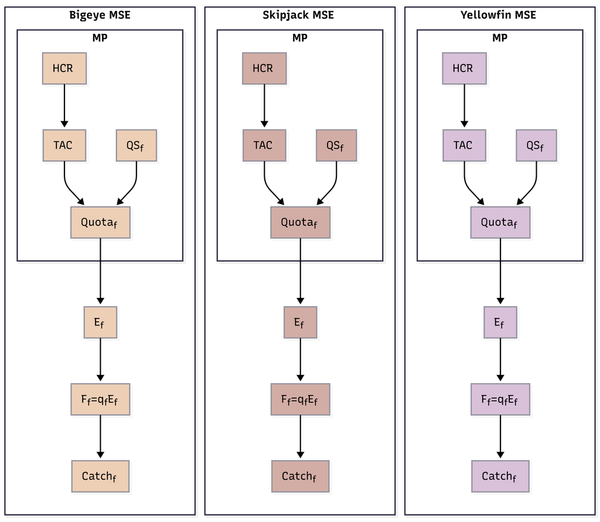

Figure 18: Representation of the single-stock MSE approach to derive catch per stock. $QS_f$ represents the quota share per fleet. $E$ represents effort. $q$ represents catchability. $f$ subindex represents fleets.

### 6.2 Multi-Stock Approach

In a multi-stock framework, stock-specific advice can be conflicting when different stocks are caught within the same fishery. In most cases, in order to not exceed the TAC of one stock (*choke stock or species*), the catch of the other two stocks may be lower than their TAC. Two approaches were tested to calculate the catch for the three stocks: minimum and mixed effort. In both cases, the *FcubEcon* methodology (Hoff et al., 2010) was used to calculate fishing mortality ($F$) and catch.

#### 6.2.1 Minimum Effort

The annual management advice was produced based on the minimum effort among the three stocks (Figure 19).

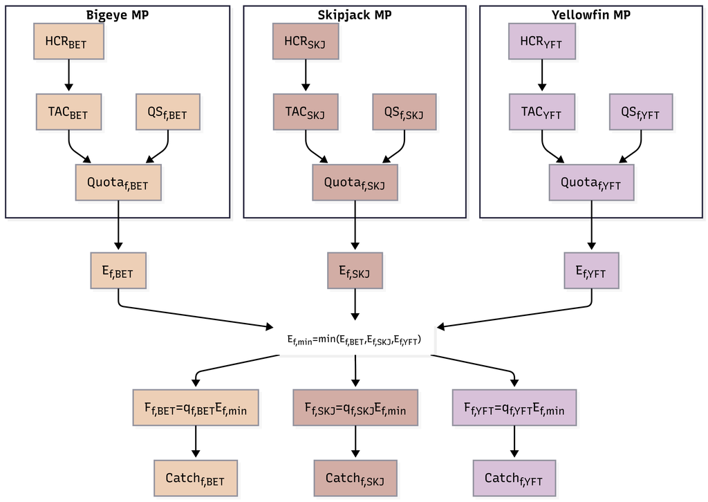

Figure 19: Representation of the minimum effort approach to derive catch per stock. $QS_f$ represents the quota share per fleet. $E$ represents effort. $q$ represents catchability. $f$ subindex represents fleets.

#### 6.2.2 Mixed Effort

The annual management advice was produced based on a mixed effort, following the *FcubEcon* approach (Hoff et al., 2010), among the three stocks. A summary of these steps is shown in Figure 20.

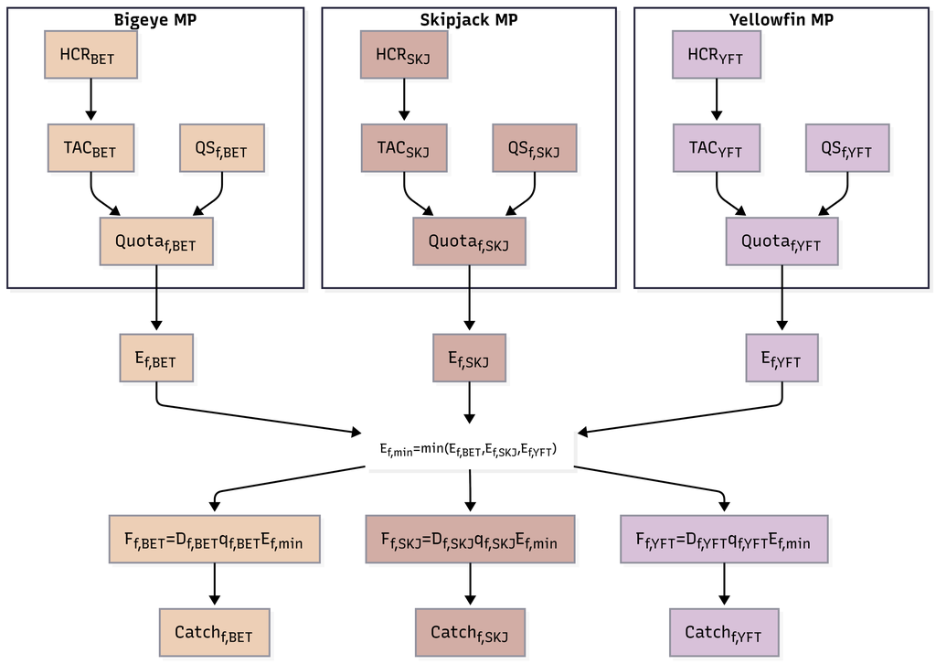

Figure 20: Representation of the mixed effort approach to derive catch per stock. $QS_f$ represents the quota share per fleet. $E$ represents effort. $q$ represents catchability. $f$ subindex represents fleets.

In this case, $D_{f,STOCK}$ is calculated as:

$$D_{f,STOCK} = \frac{1+\frac{E_{f,STOCK}}{E_{f,min}}}{2}$$

Note that $D_{f,STOCK}\geq 1$, where $D_{f,STOCK}=1$ for the *choke* stock and $D_{f,STOCK}>1$ for the other two stocks.

## 7 Performance Metrics

18 PMs have been developed for the TT MSE (Table 11) and are grouped into four types:

- **Status**: metrics related to stock status
- **Safety**: metrics related to the probability of the stock not falling below the biological reference points
- **Yield**: metrics related to the catch in the projection years
- **Stability**: metrics related to the variation in the catches or TAC between management cycles

Each PM was calculated for every Reference OM. Examples of each PM is given below.

Table 11: Performance metrics and description.

| Type | Metric | Symbol | Description |
| --- | --- | --- | --- |
| Status | Minimum spawner biomass relative to $B_{msy}$ | $minB$ | Minimum $B/B_{msy}$ value |
| Status | Mean spawner biomass relative to $B_{msy}$ | $meanB$ | Geometric mean of $B/B_{msy}$ |
| Status | Mean fishing mortality relative to $F_{msy}$ | $meanF$ | Geometric mean of $F/F_{msy}$ |
| Status | Probability (%) of being in the Kobe green quadrant | $PGK$ | Proportion of years in green quadrant (see Figure 16) |
| Status | Probability (%) of being in the Kobe red quadrant | $PRK$ | Proportion of years in red quadrant (see Figure 16) |
| Safety | Probability (%) of $B>B_{lim}$ | $PBlim$ | Proportion of years that $B>B_{lim}$ |
| Safety | Probability (%) of $B_{lim}<B<B_{msy}$ | $PBmsy$ | Proportion of years that $B_{lim}<B<B_{msy}$ |
| Yield | Mean catch (short term) | $Csrt$ | Mean catch from 1 to 3 years |
| Yield | Mean catch (medium term) | $Cmed$ | Mean catch from 5 to 10 years |
| Yield | Mean catch (long term) | $Clon$ | Mean catch from 15 to 25 years |
| Yield | Mean TAC (short term) | $Tsrt$ | Mean TAC from 1 to 3 years |
| Yield | Mean TAC (medium term) | $Tmed$ | Mean TAC from 5 to 10 years |
| Yield | Mean TAC (long term) | $Tlon$ | Mean TAC from 15 to 25 years |
| Yield | Mean TAC uptake | $Tupt$ | Mean of caught TAC (%) over years |
| Stability | Mean absolute proportional change (%) in TAC | $Tc$ | Mean of $\mid\frac{TAC_t - TAC_{t-1}}{TAC_{t-1}}\mid$ |
| Stability | Standard deviation in TAC | $Tsd$ | TAC standard deviation |
| Stability | Probability (%) of TAC change over a certain level | $PTcx$ | Proportion of management cycles when the ratio of change $\frac{TAC_y - TAC_{y-1}}{TAC_{y-1}} > 10\%$ |
| Stability | Maximum amount of TAC change (%) between management periods | $Tcmax$ | Maximum ratio of TAC change |

### 7.1 Examples

#### 7.1.1 Status

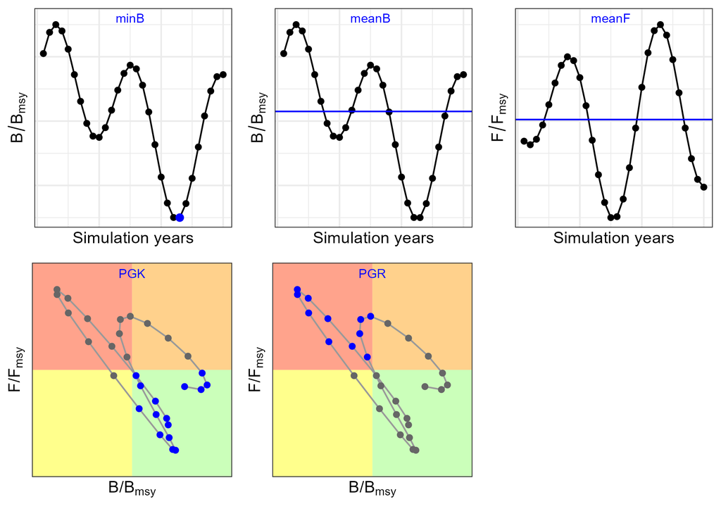

Figure 21: Status performance metrics. The blue dots or lines indicate the meaning of the metric. Find more details in Table 11.

#### 7.1.2 Safety

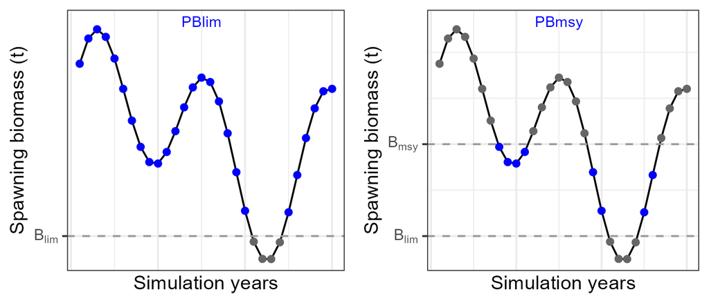

Figure 22: Safety performance metrics. The blue dots indicate the meaning of the metric. Find more details in Table 11.

#### 7.1.3 Yield

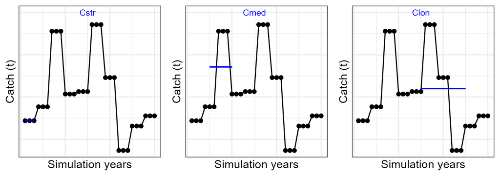

Figure 23: Yield performance metrics. The blue lines indicate the meaning of the metric. Find more details in Table 11.

#### 7.1.4 Stability

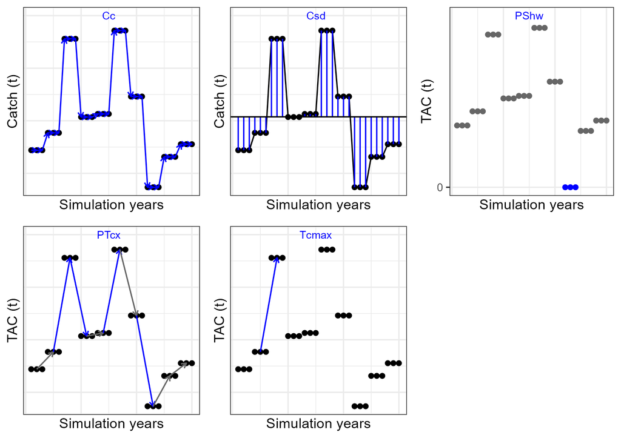

Figure 24: Stability performance metrics. The blue lines, arrows, or dots indicate the meaning of the metric. Find more details in Table 11.

## 8 Glossary

| Term | Definition |
| --- | --- |
| TT | Tropical tunas |
| BET | Bigeye |
| SKJ | Skipjack |
| YFT | Yellowfin |
| OM | Operating model |
| CMP | Candidate management procedure |
| PM | Performance metric |
| TTSG | Tropical Tunas Species Group |
| SS3 | Stock Synthesis 3 platform |
| ESS | Effective sample size |
| M | Natural mortality |
| sigmaR | Variability in recruitment |
| h | Steepness in the stock-recruit function |
| OEM | Observation error model |
| HCR | Harvest control rule |
| TAC | Total Allowable Catch |

## References

Francis, R.I.C.C., 2011. Data weighting in statistical fisheries stock assessment models. Canadian Journal of Fisheries and Aquatic Sciences 68, 1124–1138. https://doi.org/10.1139/f2011-025

Garcia, D., Sánchez, S., Prellezo, R., Urtizberea, A., Andrés, M., 2017. FLBEIA: A simulation model to conduct Bio-Economic evaluation of fisheries management strategies. SoftwareX 6, 141–147. https://doi.org/10.1016/j.softx.2017.06.001

Hamel, O.S., Cope, J.M., 2022. Development and considerations for application of a longevity-based prior for the natural mortality rate. Fisheries Research 256, 106477. https://doi.org/10.1016/j.fishres.2022.106477

Hoff, A., Frost, H., Ulrich, C., Damalas, D., Maravelias, C.D., Goti, L., Santurtún, M., 2010. Economic effort management in multispecies fisheries: The FcubEcon model. ICES Journal of Marine Science 67, 1802–1810. https://doi.org/10.1093/icesjms/fsq076

ICCAT, 2025. Report of the 2025 ICCAT Atlantic Bigeye tuna Stock Assessment Meeting (No. SCRS/2025/011). ICCAT (International Commission for the Conservation of Atlantic Tunas).

ICCAT, 2024. [Report of the 2024 ICCAT yellowfin tuna stock assessment meeting](https://www.iccat.int/Documents/CVSP/CV081_2024/n_2/CV08102009.pdf) (No. SCRS/2024/009). ICCAT (International Commission for the Conservation of Atlantic Tunas).

ICCAT, 2022. [Report of the 2022 skipjack stock assessment meeting](https://www.iccat.int/Documents/CVSP/CV079_2022/n_1/CV079010419.pdf) (No. SCRS/2022/008). ICCAT (International Commission for the Conservation of Atlantic Tunas).

Lorenzen, K., 2005. Population dynamics and potential of fisheries stock enhancement: Practical theory for assessment and policy analysis. Phil. Trans. R. Soc. B 360, 171–189. https://doi.org/10.1098/rstb.2004.1570

Lorenzen, K., 1996. The relationship between body weight and natural mortality in juvenile and adult fish: A comparison of natural ecosystems and aquaculture. Journal of Fish Biology 49, 627–642. https://doi.org/10.1111/j.1095-8649.1996.tb00060.x

Methot, R.D., Wetzel, C.R., 2013. Stock synthesis: A biological and statistical framework for fish stock assessment and fishery management. Fisheries Research 142, 86–99. https://doi.org/10.1016/j.fishres.2012.10.012

Pedersen, M.W., Berg, C.W., 2017. A stochastic surplus production model in continuous time. Fish and Fisheries 18, 226–243. https://doi.org/10.1111/faf.12174

Richards, F.J., 1959. A Flexible Growth Function for Empirical Use. Journal of Experimental Botany 10, 290–301. https://doi.org/10.1093/jxb/10.2.290

Schnute, J., 1981. A versatile growth model with statistically stable parameters. Canadian Journal of Fisheries and Aquatic Sciences 38, 1128–1140. https://doi.org/10.1139/f81-153

Waterhouse, L., Sampson, D.B., Maunder, M., Semmens, B.X., 2014. Using areas-as-fleets selectivity to model spatial fishing: Asymptotic curves are unlikely under equilibrium conditions. Fisheries Research 158, 15–25. https://doi.org/10.1016/j.fishres.2014.01.009